# HW2.Q1.Ko

```r
head(mammals,5)
```

```
##                    body brain
## Arctic fox        3.385  44.5
## Owl monkey        0.480  15.5
## Mountain beaver   1.350   8.1
## Cow             465.000 423.0
## Grey wolf        36.330 119.5
```

## 1

**(a)** According to the scatterplot, there seems to be a linear relationship between body weight and brain weight. However, by a quick glance, we can notice that most of the data points are overestimated and and variance increases as x increases, so both assumption 1 and 2 are violated.

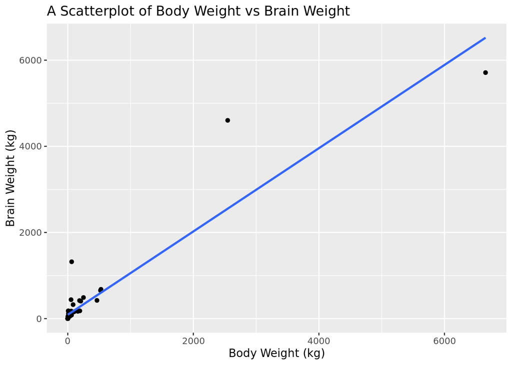

```r
# DON'T HAVE TO REMOVE OUTLIERS IN THIS STAGE.
ggplot(mammals, aes(x = body, y = brain)) +
  geom_point() +
  geom_smooth(method = "lm", se = FALSE) +
  labs(x = "Body Weight (kg)", y = "Brain Weight (kg)", title = "A Scatterplot of Body Weight vs Brain Weight")
```

**(b)** However, when we take a look at the residual plot, it violates assumption 1 (errors have mean 0), but assumption 2 (errors have constant variance) is violated as as x gets bigger, variation also gets bigger.

```r
result <- lm(brain ~ body , data= mammals)
yhat <- result$fitted.values
res <- result$residuals

residual_mammals <- data.frame(mammals ,yhat,res)
residual_mammals
```

```
##                               body   brain       yhat         res
## Arctic fox                   3.385   44.50   94.27599  -49.775986
## Owl monkey                   0.480   15.50   91.46831  -75.968314
## Mountain beaver              1.350    8.10   92.30917  -84.209166
## Cow                        465.000  423.00  540.42521 -117.425207
## Grey wolf                   36.330  119.50  126.11721   -6.617209
## Goat                        27.660  115.00  117.73769   -2.737686
## Roe deer                    14.830   98.20  105.33754   -7.137537
## Guinea pig                   1.040    5.50   92.00955  -86.509552
## Verbet                       4.190   58.00   95.05402  -37.054016
## Chinchilla                   0.425    6.40   91.41516  -85.015157
## Ground squirrel              0.101    4.00   91.10201  -87.102012
## Arctic ground squirrel       0.920    5.70   91.89357  -86.193573
## African giant pouched rat    1.000    6.60   91.97089  -85.370893
## Lesser short-tailed shrew    0.005    0.14   91.00923  -90.869229
## Star-nosed mole              0.060    1.00   91.06239  -90.062386
## Nine-banded armadillo        3.500   10.80   94.38713  -83.587133
## Tree hyrax                   2.000   12.30   92.93739  -80.637389
## N.A. opossum                 1.700    6.30   92.64744  -86.347440
## Asian elephant            2547.000 4603.00 2552.67064 2050.329355
## Big brown bat                0.023    0.30   91.02663  -90.726626
## Donkey                     187.100  419.00  271.83587  147.164133
## Horse                      521.000  655.00  594.54900   60.450996
## European hedgehog            0.785    3.50   91.76310  -88.263096
## Patas monkey                10.000  115.00  100.66936   14.330640
## Cat                          3.300   25.60   94.19383  -68.593834
## Galago                       0.200    5.00   91.19770  -86.197695
## Genet                        1.410   17.50   92.36716  -74.867156
## Giraffe                    529.000  680.00  602.28097   77.719025
## Gorilla                    207.000  406.00  291.06914  114.930856
## Grey seal                   85.000  325.00  173.15659  151.843413
## Rock hyrax-a                 0.750   12.30   91.72927  -79.429268
## Human                       62.000 1320.00  150.92717 1169.072829
## African elephant          6654.000 5712.00 6522.07123 -810.071227
## Water opossum                3.500    3.90   94.38713  -90.487133
## Rhesus monkey                6.800  179.00   97.57657   81.423428
## Kangaroo                    35.000   56.00  124.83177  -68.831769
## Yellow-bellied marmot        4.050   17.00   94.91871  -77.918706
## Golden hamster               0.120    1.00   91.12038  -90.120376
## Mouse                        0.023    0.40   91.02663  -90.626626
```

[output cut: 8 more lines]

```
## Desert hedgehog              0.550    2.40   91.53597  -89.135969
## Giant armadillo             60.000   81.00  148.99418  -67.994178
## Rock hyrax-b                 3.600   21.00   94.48378  -73.483783
## Raccoon                      4.288   39.20   95.14873  -55.948733
## Rat                          0.280    1.90   91.27502  -89.375015
## E. American mole             0.075    1.20   91.07688  -89.876883
## Mole rat                     0.122    3.00   91.12231  -88.122309
## Musk shrew                   0.048    0.33   91.05079  -90.720788
## Pig                        192.000  180.00  276.57170  -96.571699
## Echidna                      3.000   25.00   93.90389  -68.903885
## Brazilian tapir            160.000  169.00  245.64382  -76.643815
## Tenrec                       0.900    2.60   91.87424  -89.274243
## Phalanger                    1.620   11.40   92.57012  -81.170120
## Tree shrew                   0.104    2.50   91.10491  -88.604912
## Red fox                      4.235   50.40   95.09751  -44.697508
```

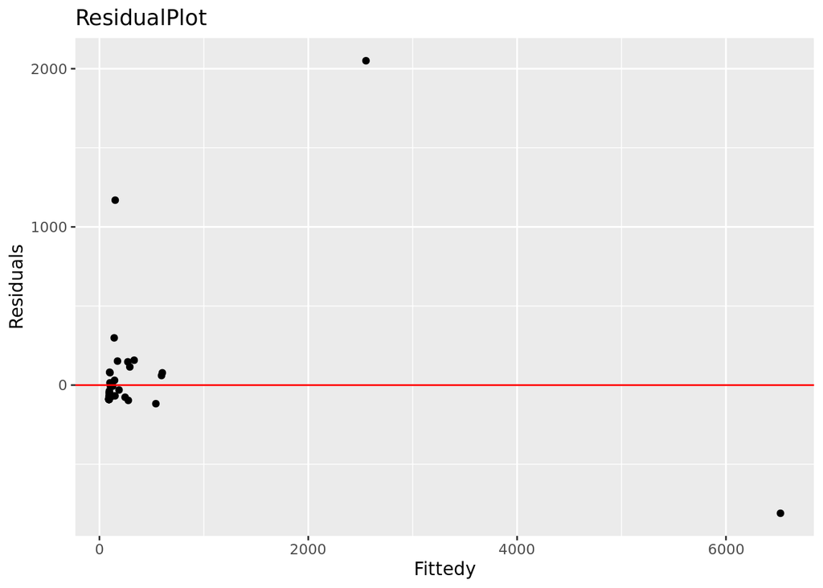

```r
ggplot(residual_mammals ,aes(x = yhat , y = res)) +
  geom_point() +
  geom_hline(yintercept=0,color="red") +
  labs(x="Fittedy", y="Residuals", title="ResidualPlot")
```

**(c)** As both assumption 1 & 2 are violated from previous plot, we have to transform response first, then predictor if issue is still present.